# HW04: Calibration of models.

### Exercise 2.1: Maximum likelihood fit to an AR+GARCH model with Student's t distribution.

Assume that the innovations $$ u_t \sim \mathcal{t} \left(loc=0, scale=\sigma, \gamma\right) $$ follow a Student's t distribution of $\gamma$ degrees of freedom centered at $0$, whose scale parameter is $\sigma$.

Design a function to fit an AR + GARCH model with Student's t noise to the time series $\left(X_1, X_2, \ldots, X_T \right)$.

**The function should be implemented in the file `my_time_series.py`**.

```
--- Fitting AR(p) + GARCH(r,s) assuming Student's t noise ---

Exact parameters (from the simulation generating process):
phi_0: 0.3 | phi: [0.1 0.3]
kappa: 0.1 | alpha: [0.27] | beta: [0.7]

Maximum likelihood estimates (Student t noise):
phi_0: 0.361 | phi: [0.1417]
kappa: 0.0763 | alpha: [0.228] | beta: [0.7448]
Degrees of freedom (nu): 52.9935

Optimization Info:
Optimization terminated successfully

--- Visualizing Standardized Innovations (Epsilon) ---
```

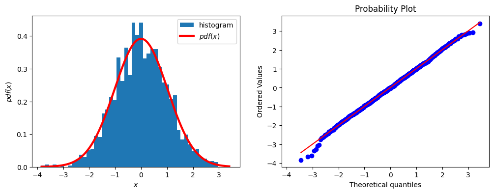

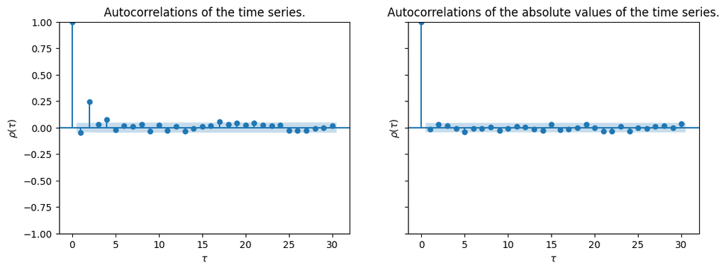

```python
### Execution: Fit AR+GARCH with Student's t noise

print("--- Fitting AR(p) + GARCH(r,s) assuming Student's t noise ---")

# Seed for the degrees of freedom (nu)
nu_seed = 5.0

# Call the newly implemented function from my_time_series.py
phi_0_ML_t, phi_ML_t, kappa_ML_t, alpha_ML_t, beta_ML_t, nu_ML_t, info_t = fit_AR_GARCH_ML_student_t_noise(
    X,
    phi_0_seed=phi_0,
    phi_seed=phi,
    kappa_seed=kappa,
    alpha_seed=alpha,
    beta_seed=beta,
    nu_seed=nu_seed
)

print('\nExact parameters (from the simulation generating process):')
print(f"phi_0: {np.round(phi_0, 4)} | phi: {np.round(phi, 4)}")
print(f"kappa: {np.round(kappa, 4)} | alpha: {np.round(alpha, 4)} | beta: {np.round(beta, 4)}")

print('\nMaximum likelihood estimates (Student t noise):')
print(f"phi_0: {np.round(phi_0_ML_t, 4)} | phi: {np.round(phi_ML_t, 4)}")
print(f"kappa: {np.round(kappa_ML_t, 4)} | alpha: {np.round(alpha_ML_t, 4)} | beta: {np.round(beta_ML_t, 4)}")
print(f"Degrees of freedom (nu): {np.round(nu_ML_t, 4)}")

print('\nOptimization Info:')
print(info_t.message)


# Analyzing the residuals of the new Student's t model

u_t, h_t = residuals_ARMA_GARCH(
    X,
    phi_0=phi_0_ML_t,
    phi=phi_ML_t,
    theta=[],
    kappa=kappa_ML_t,
    alpha=alpha_ML_t,
    beta=beta_ML_t
)

# Standardized innovations
epsilon_t = u_t / np.sqrt(h_t)

# Display tests. Since we assumed a Student's t distribution, the residuals
# might show heavier tails than a pure Gaussian curve in the QQ-plot.
print("\n--- Visualizing Standardized Innovations (Epsilon) ---")
tests_gaussian_white_noise(epsilon_t)
```

**Analysis and Conclusions**

After fitting the AR(p) + GARCH(r,s) model assuming a Student's t distribution for the innovations, we can draw the following key conclusions:

**Parameter estimates comparison:**

- The estimated parameters ($\phi, \kappa, \alpha, \beta$) under the Student's t assumption are virtually identical to those obtained under the Gaussian assumption.
- This suggests that introducing the Student's t distribution did not fundamentally alter the underlying volatility dynamics (the GARCH structure) of this specific case.

In summary, the calibration function works exactly as intended. It is flexible enough to accommodate heavy-tailed distributions when necessary, but smart enough to revert to a Gaussian-like fit when the underlying data does not exhibit extreme tail risk.

## Exercise 3: Models of financial time series

Consider the time series of prices of an asset measured at discrete times $$ \left\{S_0, S_1, \ldots, S_T \right\}. $$

The corresponding time series of log-returns is $$ \left\{X_1, X_2, \ldots, X_{T} \right\} $$ with $X_t = \log{\frac{S_t}{S_{t-1}}}, \ \ t= 1, 2, \ldots, T$.

Asset returns typically have some common characteristics. It is important to understand the implications of these properties and to identify models that can account for these features.

References:

1. Cont, Rama. (2002). Empirical Properties of Asset Returns: Stylized Facts and Statistical Issues. Quantitative Finance, pp. 223-236. DOI: 10.1088/1469-7688/1/2/304. [http://rama.cont.perso.math.cnrs.fr/pdf/empirical.pdf]
2. https://towardsdatascience.com/introduction-to-quantitative-finance-part-i-stylised-facts-of-asset-returns-5190581e40ea

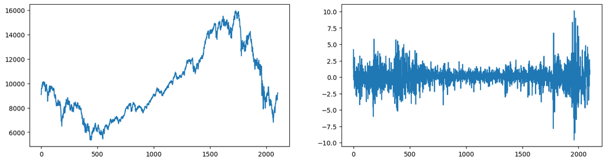

```python
# Load the time series of prices and store it in a numpy array.
prices = pd.read_csv("ibex35raw.csv")
prices = np.ravel(pd.DataFrame.to_numpy(prices))

# Compute the log-returns.

# log_returns = 100.0 * np.log(prices[1:] / prices[:-1]) # log-returns
log_returns = 100.0 * np.diff(np.log(prices)) # log-differences with lag 1 (equivalent to log-returns)

# Plot the time series.
fig, axs = plt.subplots(1, 2, figsize=(16, 4))
_ = axs[0].plot(prices)
_ = axs[1].plot(log_returns)
```

#### Non-Gaussianity (heavy tails, leptokurtic data).

In the Black-Scholes model, it is assumed that the log-returns are iid normal random variables. Empirically, one observes that the distribution of historical values of the log-returns is heavy-tailed; that is, the probability of large positive and negative returns is much larger that what a normal model would predict.

```python
from scipy.stats import skew, kurtosis
print('Statistics of log-returns')
print(
    (
        'Mean = {:.6f}\n'
        + 'Standard deviation (volatility) = {:.4f} \n'
        + 'Variance = {:.4f} \n'
        + 'Asymmetry coefficient = {:.4f} \n'
        + 'Kurtosis = {:.4f} \n'
        + 'Excess kurtosis = {:.4f} \n'
    ).format(
        np.mean(log_returns),
        np.std(log_returns),
        np.var(log_returns),
        skew(log_returns), # 0.0 for distributions that are symetric about the mean.
        kurtosis(log_returns),  # 3.0 for Gaussian.
        kurtosis(log_returns) - 3.0  # 0.0 for Gaussian.
    )
)
```

```
Statistics of log-returns
Mean = 0.000773
Standard deviation (volatility) = 1.5067
Variance = 2.2701
Asymmetry coefficient = -0.0129
Kurtosis = 5.2803
Excess kurtosis = 2.2803
```

```python
# Fit to a normal pdf (maximum likelihood).

mu_0, sigma_0 = 0.0, 1.0 # Initial seed for optimization
(mu_ML, sigma_ML), info_optimization = fit_pdf_ML(
    log_returns, norm.pdf , (mu_0, sigma_0)
)

print('Maximum likelihood: mu = {:.4e}    sigma = {:.4f}'.format(
    mu_ML, sigma_ML))


print()
```

```
Maximum likelihood: mu = 7.7329e-04    sigma = 1.5067
```

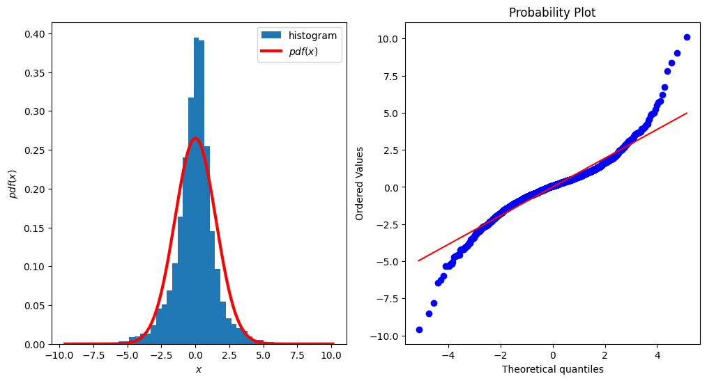

```python
# are log-returns normally distributed?

fig, axs = plt.subplots(1, 2, figsize=(12, 6))
compare_histogram_pdf(
    log_returns,
    lambda x: norm.pdf(x, mu_ML, sigma_ML),
    ax=axs[0],
)
_ = probplot(log_returns, sparams=(mu_ML, sigma_ML), dist='norm', plot=axs[1])
```

### ML fit to a student's t distribution (heavier tails than the Gaussian).

```python
# Fit to a student's t distribution (heavier tails than the Gaussian).

nu_seed, location_seed, scale_seed  = 10.0, 0.0, 1.0 # Initial seed for the optimization.

(nu_ML, location_ML, scale_ML), info_optimization = fit_pdf_ML(
    log_returns, stats.t.pdf, (nu_seed, location_seed, scale_seed)
)

print('Maximum likelihood: location = {:.4e}    scale = {:.4f}, nu = {:.4f}'.format(
    location_ML, scale_ML, nu_ML))


print()
print(info_optimization)
```

```
Maximum likelihood: location = 4.2503e-02    scale = 0.9448, nu = 2.9083

       message: Optimization terminated successfully.
       success: True
        status: 0
           fun: 1.728349135437249
             x: [ 2.908e+00  4.250e-02  9.448e-01]
           nit: 149
          nfev: 284
 final_simplex: (array([[ 2.908e+00,  4.250e-02,  9.448e-01],
                       [ 2.908e+00,  4.250e-02,  9.448e-01],
                       [ 2.908e+00,  4.250e-02,  9.448e-01],
                       [ 2.908e+00,  4.250e-02,  9.448e-01]]), array([ 1.728e+00,  1.728e+00,  1.728e+00,  1.728e+00]))
```

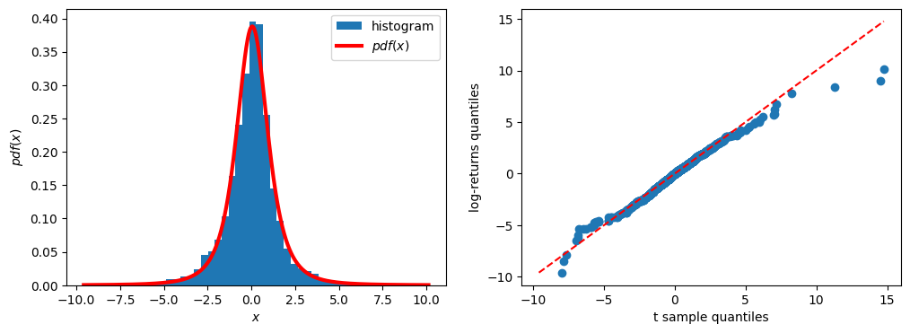

```python
# Visual test: are log-returns distributed as a Student's t?

fig, axs = plt.subplots(1, 2, figsize=(12, 4))
compare_histogram_pdf(
    log_returns,
    lambda x: stats.t.pdf(x, nu_ML, location_ML, scale_ML),
    n_bins=50,
    ax=axs[0],
)

rng = default_rng(seed=2)
reference_sample = (
    location_ML
    + scale_ML * stats.t.rvs(nu_ML, size=(len(log_returns)), random_state=rng)
)

qqplot(reference_sample, log_returns, ax=axs[1])
_ = axs[1].set_xlabel('t sample quantiles')
_ = axs[1].set_ylabel('log-returns quantiles')
```

#### Absence of linear autocorrelations.

The autocorrelations of an (approximately) stationary time series $$ \left\{X_1, X_2, \ldots, X_{T} \right\} $$ are defined as $$ \begin{aligned} \hat{\mu} & = \frac{1}{T} \sum_{t=1}^T X_t, \\ \hat{\gamma}_{\tau} & = \text{Covariance} \left[X(t), X(t + \tau) \right] \approx \frac{1}{T} \sum_{t=1}^{T - \tau} \left(X(t) - \hat{\mu} \right) \left(X(t + \tau) - \hat{\mu}\right), \\ \hat{\rho}_{\tau} & = \frac{\hat{\gamma}_{\tau}}{\hat{\gamma}_{0}}, \end{aligned} $$ where $\hat{\mu}$, $\hat{\gamma}_{0}$ are the estimates of the mean and the variance of the stationary time series.

Typically there are no significant autocorrelations among the values of the log-returns of an asset. $$ \hat{\rho}_{\tau} \approx 0, \ \ \forall \tau > 0. $$

The graph of the values of $\rho_{\tau} $ as a function the lags for $\tau \ge 0$ is known as the autocorrelogram.

The empirical estimates of the autocorrelations are not zero because of the finite size of the sample. Nevertheless their value is typically within the band (shaded area in the autocorrelogram) that quantifies the uncertainity associated to sample fluctuations. This uncertainty is $\mathcal{O}\left(1 / \sqrt{T}\right)$.

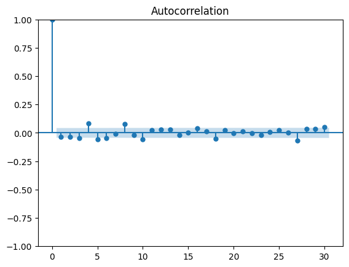

```python
# Autocorrelogram of the log-returns
from statsmodels.graphics.tsaplots import plot_acf

_ = plot_acf(log_returns, lags=30) # linear autocorrelations.
```

#### Non linear dependencies (heterocedasticity: time-dependent structure of the volatility; volatility clustering)

Even though linear dependencies (correlations) are typically not present in the time series of log-returns, one does observe that there are periods in which the volatility is larger than in others (volatility clustering). This signals the presence of significant non-linear dependencies.

This heterocedasticity (time dependent structure of the variance) is apparent from the autocorrelogram of the absolute values or of the squares of the log-returns.

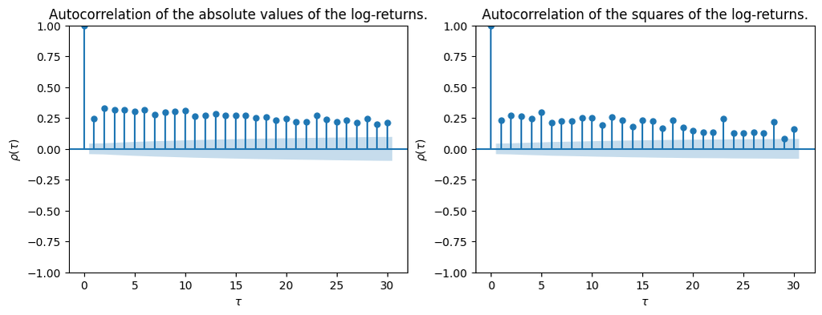

```python
# Autocorrelogram of the absolute values and of the squares of the log-returns

fig, axs = plt.subplots(1, 2, figsize=(12, 4))


_ = plot_acf(np.abs(log_returns), lags=30, ax=axs[0])
_ = axs[0].set_title('Autocorrelation of the absolute values of the log-returns.')
_ = axs[0].set_xlabel(r'$\tau$')
_ = axs[0].set_ylabel(r'$\rho(\tau)$')

_ = plot_acf(log_returns**2, lags=30, ax=axs[1]) # linear autocorrelations
_ = axs[1].set_title('Autocorrelation of the squares of the log-returns.')
_ = axs[1].set_xlabel(r'$\tau$')
_ = axs[1].set_ylabel(r'$\rho(\tau)$')
```

```python
p = len(phi)
r = len(alpha)
s = len(beta)

parameters_seed = np.zeros((1 + p) + (1 + r + s))
parameters_seed[0] = phi_0
parameters_seed[1:p+1] = phi
parameters_seed[p+1] = kappa
parameters_seed[p+2:p+r+2] = alpha
parameters_seed[p+r+2:] = beta

print(phi_0, phi, kappa, alpha, beta)
print(parameters_seed)
```

```
0.3 [0.1, 0.3] 0.1 [0.27] [0.7]
[0.3  0.1  0.3  0.1  0.27 0.7 ]
```

```
0.3607 [0.1414] 1.5067
sigma = 1.5849
```

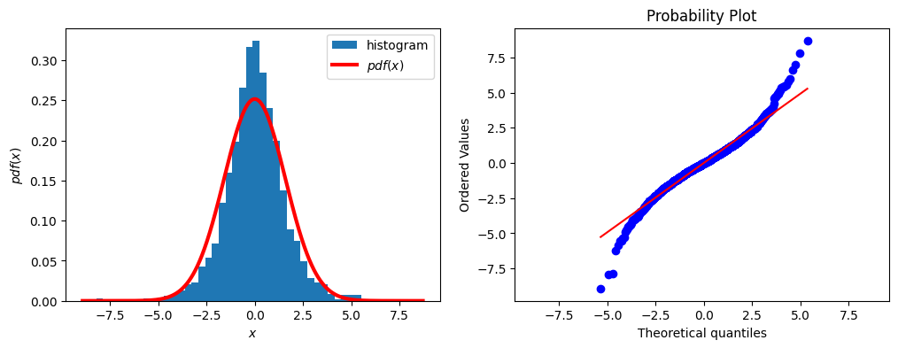

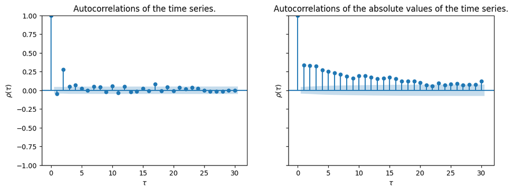

```python
print(np.round(phi_0_ML, 4), np.round(phi_ML, 4), np.round(sigma_ML, 4))

u = residuals_AR(X, phi_0_ML, phi_ML)
print('sigma = {:.4f}'.format(np.std(u)))
tests_gaussian_white_noise(u)
```

### Analysis of the IBEX 35 log-returns

```python
# Fit to AR(p) process
p = 2
phi_0_LS, phi_LS, info_optimization = fit_AR_LS(
    log_returns, phi_0_seed=0.0,  phi_seed=np.zeros(p)
)

print(np.round(phi_0_LS, 4), np.round(phi_LS, 4))

print()
print(info_optimization)
```

```
-0.0019 [-0.038  -0.0362]

     message: `ftol` termination condition is satisfied.
     success: True
      status: 2
         fun: [ 2.257e+00]
           x: [-1.860e-03 -3.799e-02 -3.624e-02]
        cost: 2.546845628902156
         jac: [[ 3.353e-05  1.180e-05  1.028e-05]]
        grad: [ 7.567e-05  2.664e-05  2.321e-05]
  optimality: 7.566916466553961e-05
 active_mask: [ 0.000e+00  0.000e+00  0.000e+00]
        nfev: 15
        njev: 8
```

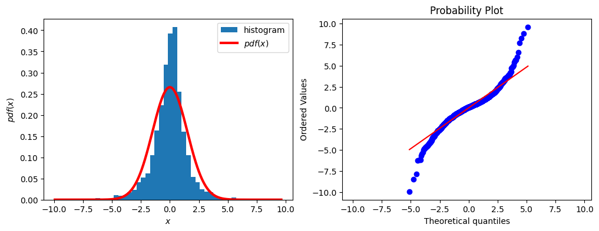

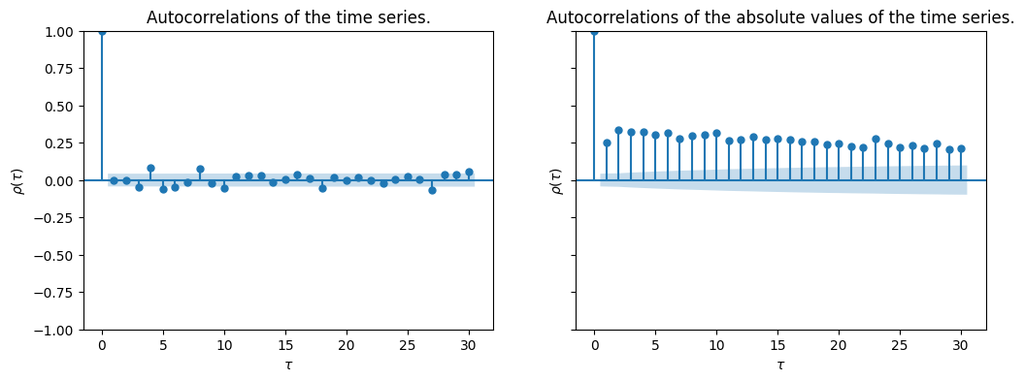

```python
# If the AR(p) model is correct, the residuals should be Gaussian white noise.
u = residuals_AR(log_returns, phi_0_LS, phi_LS)

# In this case, the residuals are still heavy-tailed and exhibit heteroskedasticity.

tests_gaussian_white_noise(u)
```

### Exercise 3.1: Models of financial time series

Historical series of asset returns exhibit common features, some of which are described in

Cont, Rama (2001) Empirical Properties of Asset Returns: Stylized Facts and Statistical Issues. Quantitative Finance, 1, 223-236. https://doi.org/10.1080/713665670

Among them, the following can be highlighted:

1. Returns are not independent. Specifically, the series is heteroscedastic: although the returns are not autocorrelated, the absolute values of the returns do exhibit autocorrelations. These autocorrelations are positive and persist over timescales of months, even years. This effect is known as volatility clustering.
2. The distribution of returns has heavy tails.
3. The distribution of returns is asymmetric.

To model the heavy tails, an AR(p) model with Student's t innovations can be used. However, this model cannot explain the volatility clustering phenomenon.

A GARCH(p, q) model for volatility can explain the heteroscedasticity of the series and, at least partially, the heavy tails.

1. The goal of this assignement is to fit different models to the series of log-returns of the IBEX 35.
   1. Gaussian innovations.
   2. Student's t innovations.
   3. AR(1) + Gaussian noise.
   4. AR(1) + Student's t noise.
   5. AR(1) + GARCH(1, 1) + Gaussian noise.
   6. AR(1) + GARCH(1, 1) + Student's t noise.
2. Numerically, maximizing the likelihood to fit the model to the data is a challenging problem: it involves optimization in a high-dimensional parameter space, with constraints (the model parameters must be such that the process is stationary). Numerical optimization algorithms are iterative procedures that start from a user-provided seed. The value of the seed value must be chosen carefully to ensure that the algorithm converges to the global minimum rather than diverging or converging to a suboptimal local minimum. To ensure a good fit of the model, it may be necessary to:
   1. Run the algorithm with different initial seeds. The choice of initial seed can be guided by the statistical properties of the series (e.g., using parameters that are compatible the sample unconditional moments estimated from the sample) or by using parameter values from fits of simpler models (e.g. the $phi_1$ parameter in a fit to an AR(1) model can be used as an initial value for an AR(1) + GARCH(1, 1) model.
   2. Implement constraints if necessary.
   3. Explore different optimization methods.

Useful information can be found in the reference page for the optimization utilities provided by scipy is https://docs.scipy.org/doc/scipy/reference/optimize.html

3. Make sure to determine in the different models whether the series of residuals $\left\{u_t \right\}$, and $\left\{\epsilon_t = \frac{u_t}{\sqrt{h_t}}\right\}$, have the properties that are expected: the type of distribution they have, whether or not thet are uncorrelated, independent, etcetera. Among the tests to be performed, at least the following should be done:
   1. Autocorrelation diagram for the series $\{\epsilon_t\}_{t \geq 1}$.
   2. Autocorrelation diagram for the absolute values $\{|\epsilon_t|\}_{t \geq 1}$.
   3. QQ-plot to compare the empirical percentiles of $\{\epsilon_t\}_{t \geq 1}$ with those of the model distribution.
4. Comment the results obtained from a financial viewpoint. To this end, consult the references given below. In parti cular, it is important to answer the following questions:
   1. What do the parameters in the different fitted models mean? Specifically, relate their values to the empirical properties of the time series of returns.
   2. What are the values of the degrees of freedom parameter in the fitted models in which the noise is distributed as a Student's t? Provide an interpretation of the differences, if there are any.
   3. Do these models capture the asymmetry of the return distribution? Illustrate your answer if it is positive. If not, propose a model that captures this asymmetry.

References:

1. Cont, Rama (2001) Empirical Properties of Asset Returns: Stylized Facts and Statistical Issues. Quantitative Finance, 1, 223-236.https://doi.org/10.1080/713665670
2. https://towardsdatascience.com/introduction-to-quantitative-finance-part-i-stylised-facts-of-asset-returns-5190581e40ea

**Optimization Methods for Maximum Likelihood Estimation**

Let $f_X(X_1, \dots, X_T | \theta)$ be the joint probability density function of our observed log-returns.

According to Wold's Decomposition, a zero mean covariance stationary process $\{X_t\}_{t=-\infty}^{\infty}$ can be represented as follows

$$X_t = \sum_{j=0}^{\infty} \psi_j u_{t-j} + \kappa_t$$

$$\psi_0 = 1 \quad \text{and} \quad \sum_{j=0}^{\infty} |\psi_j|^2 < \infty$$

The component $u_t$ is white noise, representing the error of the optimal linear prediction for $X_t$ from the complete series of previous values of the variable: $$u_t = X_t - \hat{E}[X_t | X_{t-1}, X_{t-2}, \dots]$$

The deterministic linear component $\kappa_t$ is not correlated with $u_{t-j}$ for any value of $j$ and can be linearly predicted from the sequence of previous values of $X_t$

$$\kappa_t = \hat{E}[\kappa_t | X_{t-1}, X_{t-2}, \dots]$$

To evaluate the likelihood of the model computationally, we transform the vector of observed data $\mathbf{X}$ into the vector of residuals $\mathbf{u}$. By change of variables theorem it can be proved that

$$\hat{\theta} = \arg\min_{\theta} \left( -\sum_{t=1}^{T} \log f_X(X_t | \theta) \right) = \arg\min_{\theta} \left( -\sum_{t=1}^{T} \log f_u(u_t | \theta, \theta) \right)$$

where $\theta$ represents the vector of unknown parameters to be estimated

The `scipy.optimize.minimize` function provides several algorithms, which can be grouped into three main categories based on their underlying mathematical mechanics:

- **Gradient-Free Methods (e.g., `Nelder-Mead`):** These algorithms do not evaluate the analytical derivative (gradient) of the objective function. `Nelder-Mead` operates by creating a simplex (a geometric polytope with $N+1$ vertices in an $N$-dimensional parameter space). In each iteration, it computes the centroid $\bar{\theta}$ of the best $N$ points and attempts to replace the worst-performing vertex $\theta_{worst}$ through a reflection step $$\theta_{r} = \bar{\theta} + \rho (\bar{\theta} - \theta_{worst})$$ If the reflection improves the likelihood, it expands further; otherwise, it contracts. This geometric approach makes it exceptionally robust when the likelihood surface is noisy, discontinuous, or non-smooth.
- **Gradient-Based Unconstrained Methods (e.g., `BFGS`):** These methods accelerate convergence by utilizing the gradient $\nabla \mathcal{L}(\theta)$ and building a quasi-Newton approximation of the inverse Hessian matrix $B_k^{-1}$. The parameters are iteratively updated following the direction of steepest descent adjusted by the surface curvature: $$\theta_{k+1} = \theta_k - \alpha_k B_k^{-1} \nabla \mathcal{L}(\theta_k)$$ where $\alpha_k$ is the step size. The matrix $B_k$ is updated at each step using the secant equation $B_{k+1} s_k = y_k$ (where $s_k$ is the step and $y_k$ is the gradient difference).
- **Bounded and Constrained Methods (e.g., `SLSQP`, `L-BFGS-B`):** These algorithms solve non-linear optimization problems by combining gradient information with strict parameter boundaries. `SLSQP` (Sequential Least Squares Programming), for instance, iteratively solves a quadratic approximation of the Lagrangian function: $$\min_{d} \left( \frac{1}{2} d^T B_k d + \nabla \mathcal{L}(\theta_k)^T d \right)$$ Subject to linearized equality and inequality constraints: $$c_i(\theta_k) + \nabla c_i(\theta_k)^T d \ge 0$$ where $d = \theta_{k+1} - \theta_k$ is the optimal search direction.

- **AR Stationarity:** $|\phi_1| < 1$ to ensure the mean-reverting property of the autoregressive process.
- **Variance Positivity:** $\kappa > 0$, $\alpha > 0$, and $\beta > 0$ to guarantee that the conditional volatility $h_t$ remains strictly positive at all times.
- **Covariance Stationarity:** $\alpha + \beta < 1$ to ensure that the unconditional variance of the GARCH process is finite, meaning volatility shocks will eventually decay.
- **Heavy Tails Validity:** $\nu > 2$ when fitting the Student's t-distribution to guarantee that the second moment (variance) of the innovations is mathematically well-defined.

```python
# =======================
# 1. Gaussian innovations
# =======================

mu_norm, sigma_norm = norm.fit(log_returns)

print("* Gaussian Distribution *")
print(f"Mean (mu):        {mu_norm:.4f}")
print(f"Volatility (std): {sigma_norm:.4f}")
print("-" * 45)

# ========================
# 2. t-student innovations
# ========================

nu_t, mu_t, sigma_t = t.fit(log_returns)

print("* t-student Distribution *")
print(f"Freedom degrees (nu):   {nu_t:.4f}")
print(f"Mean (mu):              {mu_t:.4f}")
print(f"Scale (sigma):          {sigma_t:.4f}")
print("-" * 45)

# ==========================
# 3. AR(1) + Gaussian Noise
# ==========================

phi_0_seed = mu_norm
phi_seed = np.array([0.0])
sigma_seed = sigma_norm

phi_0_ar1_g, phi_ar1_g, sigma_ar1_g, info_ar1_g = fit_AR_ML_gaussian_noise(
    log_returns, phi_0_seed, phi_seed, sigma_seed
)

print("* AR(1) + Gaussian Noise *")
print(f"phi_0:                   {phi_0_ar1_g:.4f}")
print(f"phi_1:                   {phi_ar1_g[0]:.4f}")
print(f"Volatility (sigma):      {sigma_ar1_g:.4f}")
print(f"Did algorithm converged? {info_ar1_g.success}")
print("-" * 45)

# ===========================
# 4. AR(1) + t-student Noise
# ===========================

nu_seed = nu_t

# We use mean of the model AR(1) + Gaussian Noise and freedom degrees of the t-student innovations.
phi_0_ar1_t, phi_ar1_t, sigma_ar1_t, nu_ar1_t, info_ar1_t = fit_AR_ML_student_t_noise(
    log_returns, phi_0_ar1_g, phi_ar1_g, sigma_ar1_g, nu_seed
)

print("* AR(1) + t-student Noise *")
print(f"phi_0:                   {phi_0_ar1_t:.4f}")
print(f"phi_1:                   {phi_ar1_t[0]:.4f}")
print(f"Scale (sigma):           {sigma_ar1_t:.4f}")
print(f"Freedom degrees (nu):    {nu_ar1_t:.4f}")
print(f"Did algorithm converge?  {info_ar1_t.success}")
print("-" * 45)


# ==========================================
# 5. AR(1) + GARCH(1, 1) + Gaussian Noise
# ==========================================

# Initial seeds
alpha_seed = np.array([0.1])
beta_seed = np.array([0.8])
kappa_seed = np.var(log_returns) * (1.0 - alpha_seed[0] - beta_seed[0])

methods_to_try = ['SLSQP', 'L-BFGS-B', 'Nelder-Mead']

best_m5_nll = np.inf
best_m5_params = None
best_m5_method = None
best_m5_success = False

for method in methods_to_try:
    apply_cons = True if method != 'Nelder-Mead' else False
    try:
        phi_0_g5, phi_g5, kappa_g5, alpha_g5, beta_g5, info_g5 = fit_AR_GARCH_ML_gaussian_noise(
            log_returns, phi_0_ar1_g, phi_ar1_g, kappa_seed, alpha_seed, beta_seed,
            method=method, apply_constraints=apply_cons
        )

        if info_g5.success and info_g5.fun < best_m5_nll:
            best_m5_nll = info_g5.fun
            best_m5_params = (phi_0_g5, phi_g5, kappa_g5, alpha_g5, beta_g5)
            best_m5_method = method
            best_m5_success = info_g5.success
    except Exception:
        pass


p0_5, p1_5, k_5, a_5, b_5 = best_m5_params

print("* AR(1) + GARCH(1,1) + Gaussian Noise *")
print(f"Optimization method:     {best_m5_method}")
print(f"phi_0:                   {p0_5:.4f}")
print(f"phi_1:                   {p1_5[0]:.4f}")
print(f"kappa:                   {k_5:.6f}")
print(f"alpha_1:                 {a_5[0]:.4f}")
print(f"beta_1:                  {b_5[0]:.4f}")
print(f"Did algorithm converge?  {best_m5_success}")
print("-" * 45)


# ==========================================
# 6. AR(1) + GARCH(1, 1) + t-student Noise
# ==========================================

# Sequential Bootstrapping
nu_seed = nu_ar1_t

best_m6_nll = np.inf
best_m6_params = None
best_m6_method = None
best_m6_success = False

for method in methods_to_try:
    apply_cons = True if method != 'Nelder-Mead' else False
    try:
        phi_0_g6, phi_g6, kappa_g6, alpha_g6, beta_g6, nu_g6, info_g6 = fit_AR_GARCH_ML_student_t_noise(
            log_returns, p0_5, p1_5, k_5, a_5, b_5, nu_seed,
            method=method, apply_constraints=apply_cons
        )
        if info_g6.success and info_g6.fun < best_m6_nll:
            best_m6_nll = info_g6.fun
            best_m6_params = (phi_0_g6, phi_g6, kappa_g6, alpha_g6, beta_g6, nu_g6)
            best_m6_method = method
            best_m6_success = info_g6.success
    except Exception:
        pass


p0_6, p1_6, k_6, a_6, b_6, nu_6 = best_m6_params

print("* AR(1) + GARCH(1,1) + t-student Noise *")
print(f"Optimization method:     {best_m6_method}")
print(f"phi_0:                   {p0_6:.4f}")
print(f"phi_1:                   {p1_6[0]:.4f}")
print(f"kappa:                   {k_6:.6f}")
print(f"alpha_1:                 {a_6[0]:.4f}")
print(f"beta_1:                  {b_6[0]:.4f}")
print(f"Freedom degrees (nu):    {nu_6:.4f}")
print(f"Did algorithm converge?  {best_m6_success}")
print("-" * 45)
```

```
* Gaussian Distribution *
Mean (mu):        0.0008
Volatility (std): 1.5067
---------------------------------------------
* t-student Distribution *
Freedom degrees (nu):   2.9084
Mean (mu):              0.0425
Scale (sigma):          0.9448
---------------------------------------------
* AR(1) + Gaussian Noise *
phi_0:                   0.0002
phi_1:                   -0.0355
Volatility (sigma):      1.5058
Did algorithm converged? True
---------------------------------------------
* AR(1) + t-student Noise *
phi_0:                   0.0441
phi_1:                   -0.0170
Scale (sigma):           0.9438
Freedom degrees (nu):    2.9018
Did algorithm converge?  True
---------------------------------------------
```

```
* AR(1) + GARCH(1,1) + Gaussian Noise *
Optimization method:     L-BFGS-B
phi_0:                   0.0737
phi_1:                   -0.0261
kappa:                   0.019535
alpha_1:                 0.1022
beta_1:                  0.8902
Did algorithm converge?  True
---------------------------------------------
* AR(1) + GARCH(1,1) + t-student Noise *
Optimization method:     Nelder-Mead
phi_0:                   0.0825
phi_1:                   -0.0287
kappa:                   0.007669
alpha_1:                 0.0665
beta_1:                  0.9114
Freedom degrees (nu):    8.4751
Did algorithm converge?  True
---------------------------------------------
```

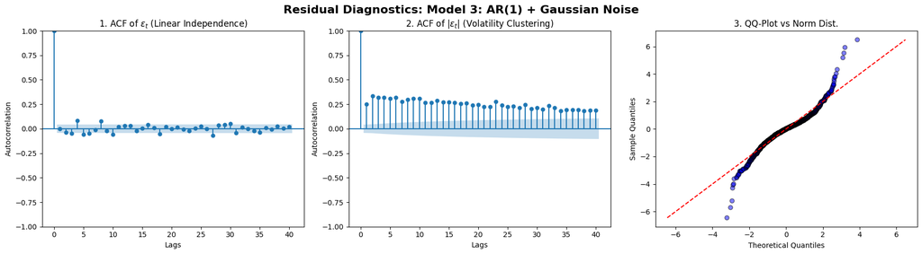

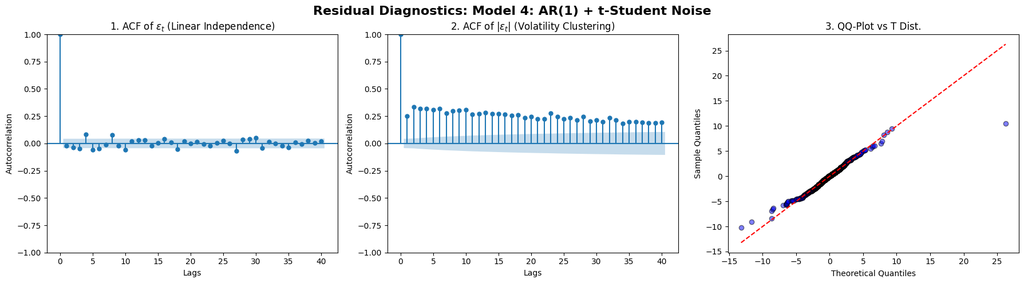

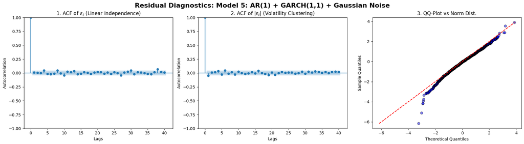

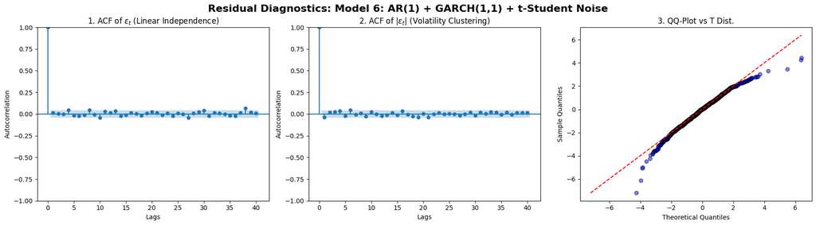

```python
T = len(log_returns)

# ==========================================
# Constant Variance
# ==========================================

# MODEL 3 AR(1) + Gaussian Noise
u_m3 = log_returns[1:] - (phi_0_ar1_g + phi_ar1_g[0] * log_returns[:-1])
h_m3 = np.full_like(u_m3, sigma_ar1_g**2)

plot_residual_diagnostics(u_m3, h_m3, dist_name='norm', model_name="Model 3: AR(1) + Gaussian Noise")


# MODEL 4 AR(1) + t-Student Noise
u_m4 = log_returns[1:] - (phi_0_ar1_t + phi_ar1_t[0] * log_returns[:-1])
h_m4 = np.full_like(u_m4, sigma_ar1_t**2)

plot_residual_diagnostics(u_m4, h_m4, dist_name='t', dist_params=(nu_ar1_t,), model_name="Model 4: AR(1) + t-Student Noise")


# ==========================================
# Dynamic Variance
# ==========================================

# MODEL 5 AR(1) + GARCH(1,1) + Gaussian Noise
p0, p1, k, a, b = p0_5, p1_5[0], k_5, a_5[0], b_5[0]
u_m5 = np.zeros(T)
h_m5 = np.zeros(T)
u_m5[0] = log_returns[0] - p0
h_m5[0] = np.var(log_returns)

for t_idx in range(1, T):
    u_m5[t_idx] = log_returns[t_idx] - (p0 + p1 * log_returns[t_idx-1])
    h_m5[t_idx] = k + a * (u_m5[t_idx-1]**2) + b * h_m5[t_idx-1]

plot_residual_diagnostics(u_m5[1:], h_m5[1:], dist_name='norm', model_name="Model 5: AR(1) + GARCH(1,1) + Gaussian Noise")


# MODEL 6 AR(1) + GARCH(1,1) + t-Student
p0, p1, k, a, b, nu = p0_6, p1_6[0], k_6, a_6[0], b_6[0], nu_6
u_m6 = np.zeros(T)
h_m6 = np.zeros(T)
u_m6[0] = log_returns[0] - p0
h_m6[0] = np.var(log_returns)

for t_idx in range(1, T):
    u_m6[t_idx] = log_returns[t_idx] - (p0 + p1 * log_returns[t_idx-1])
    h_m6[t_idx] = k + a * (u_m6[t_idx-1]**2) + b * h_m6[t_idx-1]

plot_residual_diagnostics(u_m6[1:], h_m6[1:], dist_name='t', dist_params=(nu,), model_name="Model 6: AR(1) + GARCH(1,1) + t-Student Noise")
```

#### **Analysis of Residuals Diagnostics**

A well-specified model must generate standardized innovations $\epsilon_t = \frac{u_t}{\sqrt{h_t}}$ such that $\varepsilon \sim i.i.d(0,1)$. We evaluate the empirical properties of $\{\epsilon_t\}_{t=1}^T$ for the

- **Constant variance models:** Model 3: AR(1) + Gaussian Noise and Model 4: AR(1) + t-student Noise.
- **Dynamic variance models** Model 5: AR(1) + GARCH(1,1) + Gaussian Noise and Model 6: AR(1) + GARCH(1,1) + t-student Noise.

**Autocorrelation of Absolute Residuals: ACF of $|\epsilon_t|$**

- **Hypothesis:** Strict independence / Absence of heteroskedasticity $\text{Corr}(|\epsilon_t|, |\epsilon_{t-k}|) = 0 \quad \forall k > 0$.
- **Constant Variance (M3, M4):** $\hat{\rho}_k(|\epsilon_t|) \gg 0$ for $k = 1, \dots, 40$. The slow decay of positive autocorrelation provides empirical proof of volatility clustering.
- **Dynamic Variance (M5, M6):** $\hat{\rho}_k(|\epsilon_t|) \approx 0 \quad \forall k > 0$.
- **Conclusion:** The GARCH(1,1) conditional variance equation effectively filters the non-linear dependence. Standardization by $\sqrt{h_t}$ yields strictly independent innovations.

**Distributional Fit: QQ-Plot of $\epsilon_t$**

- **Hypothesis:** The empirical quantiles $Q_{\epsilon}(p)$ match the theoretical quantiles $Q_{theo}(p)$ of the assumed probability distribution.
- **Gaussian Noise Assumption (M3, M5):** Both models exhibit significant deviations in the tails: $Q_{\epsilon}(p) < Q_{theo}(p)$ as $p \to 0$ and $Q_{\epsilon}(p) > Q_{theo}(p)$ as $p \to 1$. While M5 marginally improves the fit by generating some unconditional kurtosis through the GARCH process, it still fails to explain extreme market shocks.
- **t-student Noise Assumption (M4, M6):** In M4, the optimizer forces an artificially heavy tail ($\nu \approx 2.9$) to absorb the unmodeled heteroskedasticity. In M6, where $h_t$ is correctly specified ($\nu \approx 8.5$), the QQ-plot shows excellent alignment in the central quantiles. However, at the extremes, the empirical points systematically fall below the theoretical line ($Q_{\epsilon}(p) < Q_{theo}(p)$ as $p \to 0$ and $p \to 1$). This indicates that the empirical left tail is heavier (more severe crashes) and the right tail is thinner (fewer extreme rallies) than the symmetric t-Student predicts. Thus, while M6 successfully captures the intrinsic leptokurtosis, it fails to capture the negative asymmetry (skewness) of the market returns.
- **Conclusion:** Capturing the stylized facts of IBEX 35 returns requires modeling both stochastic volatility (GARCH) and a leptokurtic conditional distribution (Student's t).